Bruno Gegenhuber, PhD

POSTDOCTORAL FELLOW / HARVARD MEDICAL SCHOOL

# Bruno Gegenhuber

The molecular logic of brain development and plasticity.

I study how gene regulation, hormones, and experience shape neural circuits—across development and into maturity.

Explore my research ↗ [ORCID ↗](https://orcid.org/0000-0001-8628-1920)

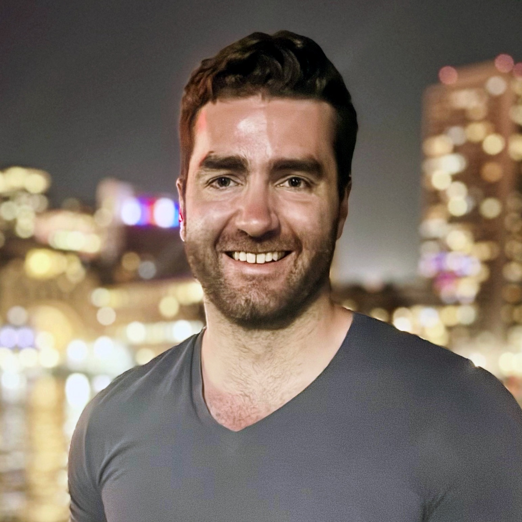

01ABOUT

## How does the brain take shape?

I am a postdoctoral fellow in [Michael Greenberg's laboratory](https://greenberg.hms.harvard.edu/people/) in the Department of Neurobiology at Harvard Medical School. **I am also an instructor in the Advanced Techniques in Molecular Neuroscience Course at Cold Spring Harbor Laboratory**.

Before Harvard, I earned my PhD at Cold Spring Harbor Laboratory, where I discovered how steroid hormones regulate neuronal gene expression to generate sex differences in the brain.

I am especially interested in leveraging fundamental biology to find new ways to re-open brain plasticity for treating disease.

02RESEARCH

## Research interests.

01 /

### Brain plasticity & critical period closure

What determines how and when the developing brain loses plasticity, and can we target these pathways to restore plasticity in adulthood? My recent work implicates astrocyte glucocorticoid receptor signaling in closing critical periods in development.

↗

02 /

### Glial endocrine sensing

Astrocytes are the gateway to the brain. How do astrocytes sense and respond to the multitude of circulating factors in the blood to alter neuronal function and behavior?

↗

03 /

### Molecular basis of trauma

How can single-cell cell-type-resolved genomic approaches reveal the fundamental principles by which stress alters brain maturation, function, and behavior?

↗

03PUBLICATIONS

## Selected publications.

[Browse PubMed ↗](https://pubmed.ncbi.nlm.nih.gov/?term=Gegenhuber+B%5BAuthor%5D)

2026

[Astrocyte glucocorticoid receptor signalling restricts neuronal plasticity ↗](https://doi.org/10.1038/s41586-026-10512-9)

**Gegenhuber B**, Sonoda T, Traunmüller L, Davis CP, Koren SA, Griffith EC, Chen C & Greenberg ME.

*Nature* · [DOI](https://doi.org/10.1038/s41586-026-10512-9) FEATURED

2022

[Gene regulation by gonadal hormone receptors underlies brain sex differences ↗](https://doi.org/10.1038/s41586-022-04686-1)

**Gegenhuber B**, Wu MV, Bronstein R & Tollkuhn J.

*Nature* · [DOI](https://doi.org/10.1038/s41586-022-04686-1)

2021

[Oestrogen engages brain MC4R signalling to drive physical activity in female mice ↗](https://scholar.google.com/citations?view_op=view_citation&hl=en&user=Niip26YAAAAJ&citation_for_view=Niip26YAAAAJ:Tyk-4Ss8FVUC)

Krause WC, Rodriguez R, **Gegenhuber B**, et al.

*Nature* · [DOI](https://doi.org/10.1038/s41586-021-04010-3)

2020

[Signatures of sex: Sex differences in gene expression in the vertebrate brain ↗](https://doi.org/10.1002/wdev.348)

**Gegenhuber B** & Tollkuhn J.

*WIREs Developmental Biology* · [DOI](https://doi.org/10.1002/wdev.348)

2019

[Sex differences in the epigenome: A cause or consequence of sexual differentiation of the brain? ↗](https://doi.org/10.3390/genes10060432)

**Gegenhuber B** & Tollkuhn J.

*Genes* · [DOI](https://doi.org/10.3390/genes10060432)

04 / CONTACT

## Let's connect.

For research conversations, collaboration, or correspondence, feel free to get in touch.

Email me ↗ [ORCID ↗](https://orcid.org/0000-0001-8628-1920) [LinkedIn ↗](https://www.linkedin.com/in/bruno-gegenhuber-973771440/) [X (@brunogegenhuber) ↗](https://x.com/brunogegenhuber) [Greenberg Lab ↗](https://greenberg.hms.harvard.edu/people/)